# Solar Potential Assessment — Bunbury

Rooftop PV yield modelling using ERA5 meteorological data and LiDAR-derived shading

Published

October 19, 2026

## 1 Overview

This report presents a rooftop solar potential assessment for the **Bunbury** site (53.114°N, −2.646°E), covering the period 2020-01-01 to 2025-12-31. Seven distinct roof surfaces have been identified and characterised.

Solar irradiance estimates are derived from pre-processed ECMWF ERA5 reanalysis data, with shading calculated from Environment Agency LiDAR digital surface models. Where structures such as outbuildings or sheds sit above ground level, the DSM is adjusted upward to reflect their true rooftop height before shading is computed.

The roof surfaces have been numbered as follows:

[figure not shown]

## 2 Site and system parameters

The table below summarises the seven roof surfaces included in the analysis. Surfaces without a recorded aspect and slope have these values extracted directly from the LiDAR-derived terrain model at the centroid location. Panel counts reflect the estimated maximum capacity of each surface.

| Surface | Latitude | Longitude | Length max (m) | Width max (m) | Panels | Height above ground (m) | Aspect (°) | Slope (°) |
| --- | --- | --- | --- | --- | --- | --- | --- | --- |
| 1 | 53.1137 | -2.6460 | 11 | 5.00 | 33 | NA | NA | NA |
| 2 | 53.1137 | -2.6459 | 5 | 4.71 | 4 | NA | NA | NA |
| 3 | 53.1137 | -2.6460 | 0 | 2.62 | 2 | NA | NA | NA |
| 4 | 53.1137 | -2.6459 | 5 | 4.71 | 4 | NA | NA | NA |
| 5 | 53.1137 | -2.6459 | 0 | 2.62 | 2 | NA | 160 | NA |
| 6 | 53.1137 | -2.6457 | 6 | 3.00 | 12 | 3 | 333 | 35 |
| 7 | 53.1137 | -2.6457 | 6 | 1.76 | 6 | 3 | 153 | 35 |

Note:  
Aspect: degrees clockwise from north. NA = derived from LiDAR aspect raster.

## 3 Method

### 3.1 Meteorological data

Hourly surface solar irradiance (global horizontal, direct normal, and diffuse horizontal components) is sourced from the **ECMWF ERA5** reanalysis archive via the `ecmwfr` package. Data are downloaded for a 40 m buffer domain around the site centroid and aggregated to daily totals. ERA5 has a native spatial resolution of ~31 km; point-level estimates are extracted by bilinear interpolation to the site coordinates.

Plane-of-array irradiance for each surface is computed from the horizontal components using the surface tilt and azimuth, accounting for direct beam projection, isotropic diffuse sky, and ground-reflected components. Where aspect and slope are not recorded in the system parameters, values are taken from the LiDAR-derived rasters described below.

### 3.2 LiDAR digital surface model and shading

A 1 m resolution Digital Surface Model (DSM) is retrieved from the **Environment Agency National LiDAR Programme** (via `nexurbr::get_gb_lidar()`), covering the local domain. The DSM represents the top surface of all features — buildings, vegetation, and ground — in metres above Ordnance Datum (OSGB36/EPSG:27700).

Slope and aspect rasters are derived from the DSM using an 8-neighbour algorithm (`terra::terrain()`). Monthly shading fractions are then calculated using `nexurbr::calc_shade()`, which casts solar position vectors (sun azimuth and elevation at sub-hourly resolution) across the DSM to identify shadowed cells for each timestep.

### 3.3 DSM adjustment for above-ground structures

Two roof surfaces (6 and 7) are located on structures with a recorded height above the surrounding ground plane (3 m). Where height values are provided in the system parameters, the DSM cell values at those locations are raised by the stated height before shading is computed. This ensures that the shading model correctly represents the elevated surface and that neighbouring obstructions are assessed relative to the true panel position rather than the ground.

The adjustment is applied to a 1 m buffer polygon around the centroid of each elevated surface, rasterised to the DSM grid.

### 3.4 Yield calculation

Panel-level yield (kWh/panel/day) is computed using `nexurbr::calc_solar_potential_point()`, combining plane-of-array irradiance with a standard system efficiency assumption. Bank-level yield is the product of per-panel yield and panel count. Results are aggregated to monthly and annual totals for reporting.

## 4 Yield calculation

```
[1] "slope derived from raster"
[1] "aspect derived from raster"
[1] "slope derived from raster"
[1] "aspect derived from raster"
[1] "slope derived from raster"
[1] "aspect derived from raster"
[1] "slope derived from raster"
[1] "aspect derived from raster"
[1] "slope derived from raster"
[1] "aspect defined by user"
[1] "slope defined by user"
[1] "aspect defined by user"
[1] "slope defined by user"
[1] "aspect defined by user"
```

## 5 Results

### 5.1 Annual yield by roof surface

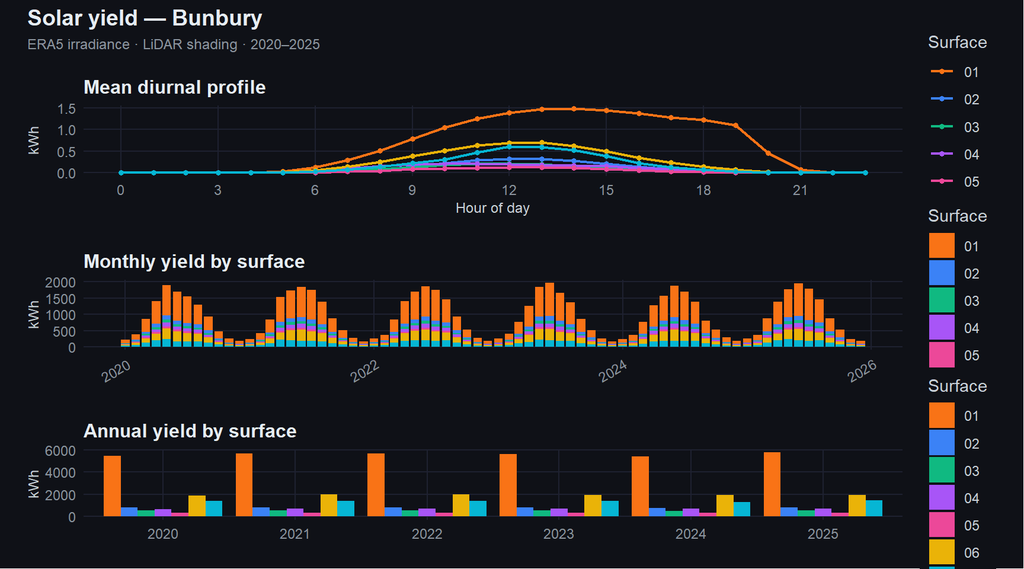

Annual yield (kWh) by roof surface and year

### 5.2 Total site yield

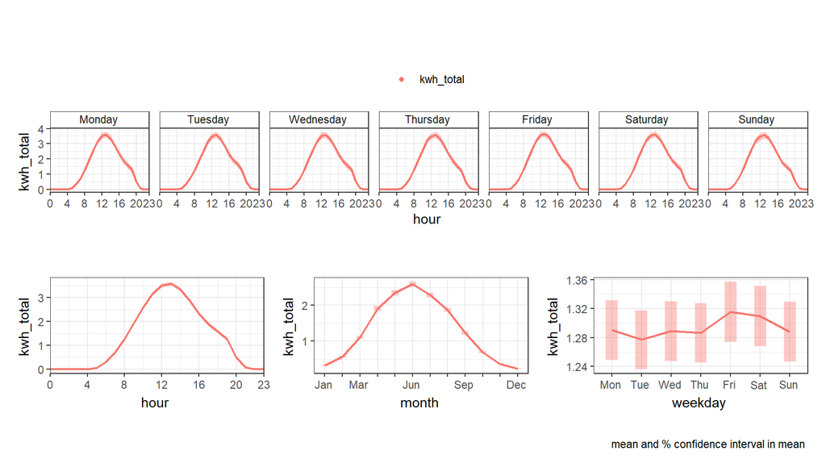

### 5.3 Annual summary table

Annual yield by surface (kWh)

| year | aspect | slope | Surface 01 | Surface 02 | Surface 03 | Surface 04 | Surface 05 | Surface 06 | Surface 07 | Total |
| --- | --- | --- | --- | --- | --- | --- | --- | --- | --- | --- |
| 2020 | 330 | 59 | 5452 | NA | NA | NA | NA | NA | NA | 5452 |
| 2021 | 330 | 59 | 5661 | NA | NA | NA | NA | NA | NA | 5661 |
| 2022 | 330 | 59 | 5646 | NA | NA | NA | NA | NA | NA | 5646 |
| 2023 | 330 | 59 | 5596 | NA | NA | NA | NA | NA | NA | 5596 |
| 2024 | 330 | 59 | 5381 | NA | NA | NA | NA | NA | NA | 5381 |
| 2025 | 330 | 59 | 5748 | NA | NA | NA | NA | NA | NA | 5748 |
| 2020 | 242 | 32 | NA | 807 | NA | NA | NA | NA | NA | 807 |
| 2021 | 242 | 32 | NA | 828 | NA | NA | NA | NA | NA | 828 |
| 2022 | 242 | 32 | NA | 832 | NA | NA | NA | NA | NA | 832 |
| 2023 | 242 | 32 | NA | 815 | NA | NA | NA | NA | NA | 815 |
| 2024 | 242 | 32 | NA | 783 | NA | NA | NA | NA | NA | 783 |
| 2025 | 242 | 32 | NA | 846 | NA | NA | NA | NA | NA | 846 |
| 2020 | 159 | 35 | NA | NA | 540 | NA | NA | NA | NA | 540 |
| 2021 | 159 | 35 | NA | NA | 540 | NA | NA | NA | NA | 540 |
| 2022 | 159 | 35 | NA | NA | 548 | NA | NA | NA | NA | 548 |
| 2023 | 159 | 35 | NA | NA | 532 | NA | NA | NA | NA | 532 |
| 2024 | 159 | 35 | NA | NA | 499 | NA | NA | NA | NA | 499 |
| 2025 | 159 | 35 | NA | NA | 571 | NA | NA | NA | NA | 571 |
| 2020 | 66 | 33 | NA | NA | NA | 683 | NA | NA | NA | 683 |
| 2021 | 66 | 33 | NA | NA | NA | 720 | NA | NA | NA | 720 |
| 2022 | 66 | 33 | NA | NA | NA | 714 | NA | NA | NA | 714 |
| 2023 | 66 | 33 | NA | NA | NA | 694 | NA | NA | NA | 694 |
| 2024 | 66 | 33 | NA | NA | NA | 693 | NA | NA | NA | 693 |
| 2025 | 66 | 33 | NA | NA | NA | 702 | NA | NA | NA | 702 |
| 2020 | 160 | 71 | NA | NA | NA | NA | 347 | NA | NA | 347 |
| 2021 | 160 | 71 | NA | NA | NA | NA | 355 | NA | NA | 355 |
| 2022 | 160 | 71 | NA | NA | NA | NA | 353 | NA | NA | 353 |
| 2023 | 160 | 71 | NA | NA | NA | NA | 348 | NA | NA | 348 |
| 2024 | 160 | 71 | NA | NA | NA | NA | 331 | NA | NA | 331 |
| 2025 | 160 | 71 | NA | NA | NA | NA | 365 | NA | NA | 365 |
| 2020 | 333 | 35 | NA | NA | NA | NA | NA | 1893 | NA | 1893 |
| 2021 | 333 | 35 | NA | NA | NA | NA | NA | 1993 | NA | 1993 |
| 2022 | 333 | 35 | NA | NA | NA | NA | NA | 1983 | NA | 1983 |
| 2023 | 333 | 35 | NA | NA | NA | NA | NA | 1944 | NA | 1944 |
| 2024 | 333 | 35 | NA | NA | NA | NA | NA | 1933 | NA | 1933 |
| 2025 | 333 | 35 | NA | NA | NA | NA | NA | 1945 | NA | 1945 |
| 2020 | 153 | 35 | NA | NA | NA | NA | NA | NA | 1414 | 1414 |
| 2021 | 153 | 35 | NA | NA | NA | NA | NA | NA | 1415 | 1415 |
| 2022 | 153 | 35 | NA | NA | NA | NA | NA | NA | 1429 | 1429 |
| 2023 | 153 | 35 | NA | NA | NA | NA | NA | NA | 1385 | 1385 |
| 2024 | 153 | 35 | NA | NA | NA | NA | NA | NA | 1312 | 1312 |
| 2025 | 153 | 35 | NA | NA | NA | NA | NA | NA | 1486 | 1486 |

### 5.4 Whole-site annual totals

Total site yield by year

| Year | Total yield (kWh) |
| --- | --- |
| 2020 | 11137 |
| 2021 | 11512 |
| 2022 | 11504 |
| 2023 | 11313 |
| 2024 | 10932 |
| 2025 | 11663 |

## 6 Discussion

The analysis draws on six years of ERA5 meteorological data (2020–2025), providing a representative picture of inter-annual variability driven by cloud cover and solar geometry at this latitude (~53°N). Yield estimates are sensitive to assumed panel efficiency and inverter losses, which use standard defaults in this version of the model; site-specific values can be substituted in https://blaisekelly.github.io/GBsolar/app.html.

Shading from neighbouring vegetation and structures is captured in the LiDAR DSM but is subject to the resolution of the 1 m dataset and the date of the survey flight. Seasonal variation in deciduous canopy is not accounted for, which may lead to a modest underestimate of summer yield for surfaces adjacent to trees.